# 320 Final Project: Kickstarter Data Analysis

Rajan Konai

May 18, 2018

# Kickstarter Campaign Analysis

Kickstarter is a global crowdfunding platform for a variety of campaigns. I am going to see what campaigns are likely to get funding and succeed. I will be using the ks-projects-201801.csv dataset available from Kaggle at https://www.kaggle.com/kemical/kickstarter-projects/data. For more info on Kickstarter, please see https://www.kickstarter.com/about?ref=global-footer.

## Reading in Data

Let’s read in the dataset from Kaggle with read_csv, and take a look at the data.

```r
kstarter <- read_csv("ks2018.csv")
head(kstarter)
```

```
## # A tibble: 6 x 15
##        ID name     category main_category currency deadline  goal launched
##     <int> <chr>    <chr>    <chr>         <chr>    <chr>    <dbl> <chr>
## 1  1.00e9 The Son~ Poetry   Publishing    GBP      10/9/20~  1000 8/11/20~
## 2  1.00e9 Greetin~ Narrati~ Film & Video  USD      11/1/20~ 30000 9/2/201~
## 3  1.00e9 Where i~ Narrati~ Film & Video  USD      2/26/20~ 45000 1/12/20~
## 4  1.00e9 ToshiCa~ Music    Music         USD      4/16/20~  5000 3/17/20~
## 5  1.00e9 Communi~ Film & ~ Film & Video  USD      8/29/20~ 19500 7/4/201~
## 6  1.00e9 Monarch~ Restaur~ Food          USD      4/1/2016 50000 2/26/20~
## # ... with 7 more variables: pledged <dbl>, state <chr>, backers <int>,
## #   country <chr>, `usd pledged` <dbl>, usd_pledged_real <dbl>,
## #   usd_goal_real <dbl>
```

## Tidying Up

Now, let’s clean the data a bit. There is a column we do not need, “usd pledged”, as we will use “usd_pledged_real”. Let’s delete the column and rename it “usd_pledged” for clarity.

Note that a couple of the columns have datatypes that don’t entirely match what the column holds. Namely the “deadline” and “launched” columns, which should have a datetime type rather than character. Let’s change that.

I am using as.Date to change the deadline and launched cols into date objects. Note that I am throwing out the hours/minutes/seconds from the launch time, but we won’t need that for our analysis. Here is some more info about how to deal with dates in R: https://www.rdocumentation.org/packages/zoo/versions/1.5-8/topics/as.Date.numeric.

```r
ks <- kstarter
ks <- subset(ks, select = -c(13))
ks <- dplyr::rename(ks, usd_pledged = usd_pledged_real, usd_goal = usd_goal_real)


ks$deadline <- as.Date(ks$deadline, "%m/%d/%Y")
ks$launched <- as.Date(ks$launched, format = "%m/%d/%Y")


ks <- ks%>%
  mutate(launch_year = lubridate::year(launched)) %>%
  mutate(deadline_year = lubridate::year(deadline))

ks$launch_year <- with(ks, ifelse(launch_year == 1970, deadline_year, launch_year))


head(ks)
```

```
## # A tibble: 6 x 16
##       ID name  category main_category currency deadline    goal launched
##    <int> <chr> <chr>    <chr>         <chr>    <date>     <dbl> <date>
## 1 1.00e9 The ~ Poetry   Publishing    GBP      2015-10-09  1000 2015-08-11
## 2 1.00e9 Gree~ Narrati~ Film & Video  USD      2017-11-01 30000 2017-09-02
## 3 1.00e9 Wher~ Narrati~ Film & Video  USD      2013-02-26 45000 2013-01-12
## 4 1.00e9 Tosh~ Music    Music         USD      2012-04-16  5000 2012-03-17
## 5 1.00e9 Comm~ Film & ~ Film & Video  USD      2015-08-29 19500 2015-07-04
## 6 1.00e9 Mona~ Restaur~ Food          USD      2016-04-01 50000 2016-02-26
## # ... with 8 more variables: pledged <dbl>, state <chr>, backers <int>,
## #   country <chr>, usd_pledged <dbl>, usd_goal <dbl>, launch_year <dbl>,
## #   deadline_year <dbl>
```

## General Data Statistics

Let’s get some statistics about top kickstarter campaigns.

```r
head(ks)
```

```
## # A tibble: 6 x 16
##       ID name  category main_category currency deadline    goal launched
##    <int> <chr> <chr>    <chr>         <chr>    <date>     <dbl> <date>
## 1 1.00e9 The ~ Poetry   Publishing    GBP      2015-10-09  1000 2015-08-11
## 2 1.00e9 Gree~ Narrati~ Film & Video  USD      2017-11-01 30000 2017-09-02
## 3 1.00e9 Wher~ Narrati~ Film & Video  USD      2013-02-26 45000 2013-01-12
## 4 1.00e9 Tosh~ Music    Music         USD      2012-04-16  5000 2012-03-17
## 5 1.00e9 Comm~ Film & ~ Film & Video  USD      2015-08-29 19500 2015-07-04
## 6 1.00e9 Mona~ Restaur~ Food          USD      2016-04-01 50000 2016-02-26
## # ... with 8 more variables: pledged <dbl>, state <chr>, backers <int>,
## #   country <chr>, usd_pledged <dbl>, usd_goal <dbl>, launch_year <dbl>,
## #   deadline_year <dbl>
```

```r
head(ks$main_category)
```

```
## [1] "Publishing"   "Film & Video" "Film & Video" "Music"
## [5] "Film & Video" "Food"
```

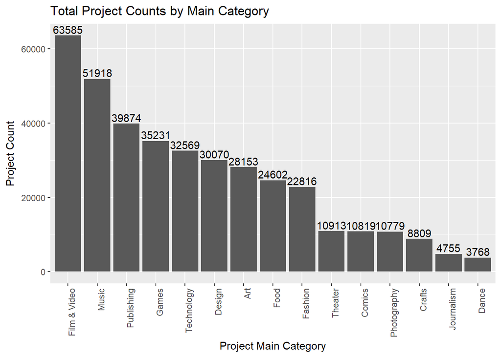

```r
ks$main_category <- factor(ks$main_category, levels = names(sort(table(ks$main_category), decreasing = TRUE)))

ks %>%
  ggplot(aes(x = main_category)) +
  geom_bar(stat = "count") +
  geom_text(stat = "count", aes(label = ..count..), vjust = -.25) +
  theme(axis.text.x = element_text(angle= 90, hjust=1)) +
  labs(x = "Project Main Category", y = "Project Count") +
  ggtitle("Total Project Counts by Main Category")
```

```r
total_proj = length(ks$ID)
total_proj
```

```
## [1] 378661
```

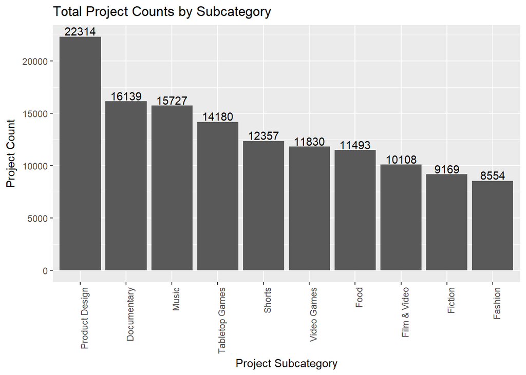

```r
# may not use below plot:

ks %>%
  group_by(category) %>%
  summarize(z = length(category)) %>%
  filter(z > 8500) %>%
  ggplot(aes(x = reorder(category,-z), y = z)) +
  geom_bar(stat = "identity") +
  geom_text(aes(label = z), vjust = -.15) +
  theme(axis.text.x = element_text(angle= 90, hjust=1)) +
  labs(x = "Project Subcategory", y = "Project Count") +
  ggtitle("Total Project Counts by Subcategory")
```

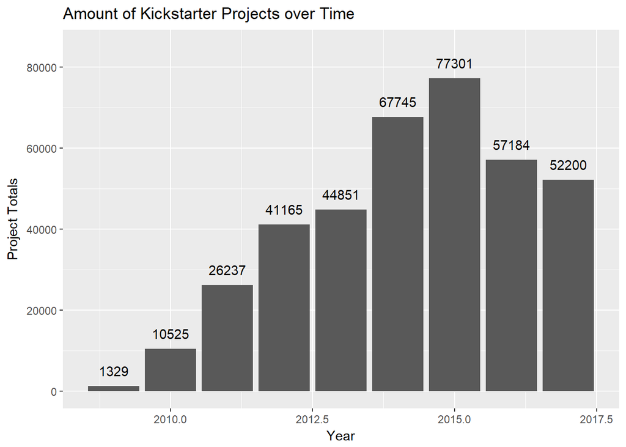

```r
ks_plot <- ks %>%
  filter(launch_year < 2018) %>%
  group_by(launch_year) %>%
  summarize(projects = n())


ks_plot %>%
  ggplot(aes(x = launch_year, y = projects)) +
  geom_bar(stat = "identity") +
  geom_text(aes(x = launch_year, y = projects, label = projects), vjust = -1) +
  scale_y_continuous(limits = c(0, 85000)) +
  labs(x = "Year", y = "Project Totals") +
  ggtitle("Amount of Kickstarter Projects over Time")
```

Looks like Film and Video is the highest category for Kickstarter projects. What percent of all projects are Film and Video?

```r
ks %>%

  filter(main_category == "Film & Video")
```

```
## # A tibble: 63,585 x 16
##         ID name           category main_category currency deadline    goal
##      <int> <chr>          <chr>    <fct>         <chr>    <date>     <dbl>
##  1  1.00e9 Greeting From~ Narrati~ Film & Video  USD      2017-11-01 30000
##  2  1.00e9 Where is Hank? Narrati~ Film & Video  USD      2013-02-26 45000
##  3  1.00e9 Community Fil~ Film & ~ Film & Video  USD      2015-08-29 19500
##  4  1.00e8 STUDIO IN THE~ Documen~ Film & Video  USD      2014-08-10 65000
##  5  1.00e9 Permaculture ~ Webseri~ Film & Video  CAD      2014-12-14 17757
##  6  1.00e8 My Moon - Ani~ Animati~ Film & Video  USD      2017-05-03 50000
##  7  1.00e9 Squatch Watch~ Webseri~ Film & Video  USD      2013-08-23 10000
##  8  1.00e9 Zen in Americ~ Documen~ Film & Video  USD      2013-10-21 10000
##  9  1.00e9 WE ARE ONE: S~ Documen~ Film & Video  USD      2013-10-01  2500
## 10  1.00e9 Star and the ~ Narrati~ Film & Video  USD      2013-02-23  8000
## # ... with 63,575 more rows, and 9 more variables: launched <date>,
## #   pledged <dbl>, state <chr>, backers <int>, country <chr>,
## #   usd_pledged <dbl>, usd_goal <dbl>, launch_year <dbl>,
## #   deadline_year <dbl>
```

```r
pct_film_video = sum(ks$main_category == "Film & Video")/length(ks$ID)

pct_film_video
```

```
## [1] 0.1679206
```

Only 16.7% of Kickstarter projects are in the Film & Video category.

## What countries are projects coming from?

Notice how I took a log of the y-axis to make the data more readable, as the data was highly skewed towards US project submissions.

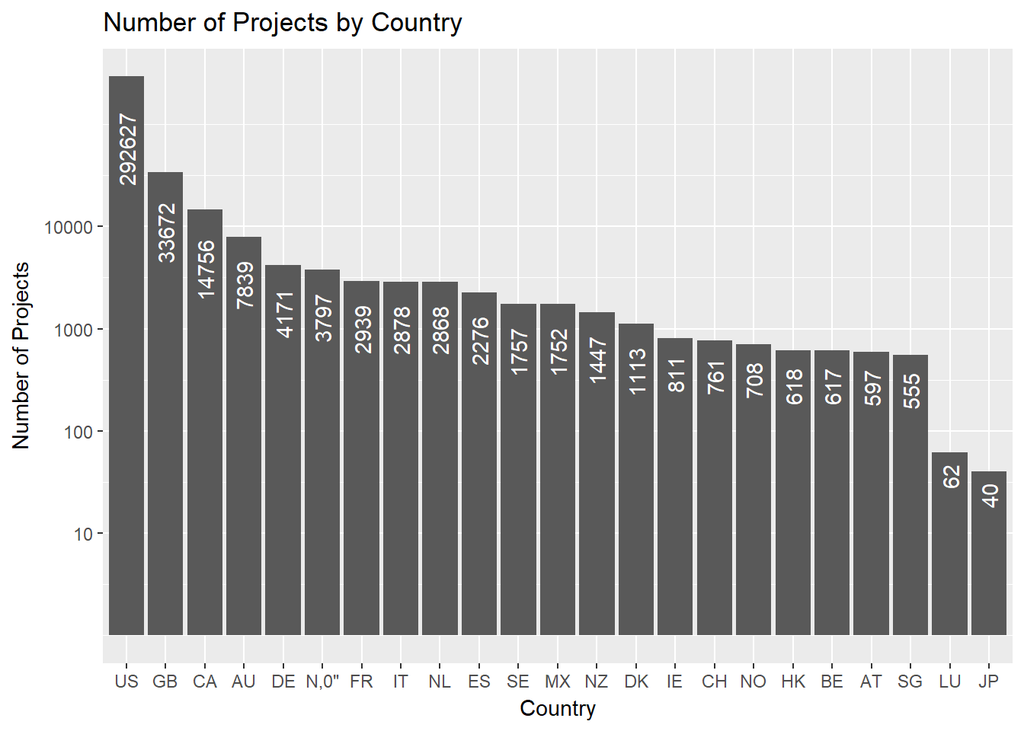

```r
ksplt <-ks %>%

  group_by(country) %>%
  summarize(num = n()) %>%
  arrange(desc(num)) %>%
  ggplot(aes(reorder(country,-num),num)) +
  geom_bar(stat = "identity") +
  scale_y_log10(breaks = c(10, 100, 1000, 10000)) +
  labs(x = "Country", y = "Number of Projects") +
  geom_text(aes(label = num), vjust = .5, hjust = 1.5, angle = 90, color = "white") +
  ggtitle("Number of Projects by Country")

ksplt
```

## Project Types over the Years

Now let’s take a look and see how projects have changed over the years. I will do this using a method called faceting, which you can read more about at: https://plot.ly/ggplot2/facet_wrap/. Here, I used the column launch_year, which I previously created. It holds the year the project was launched.

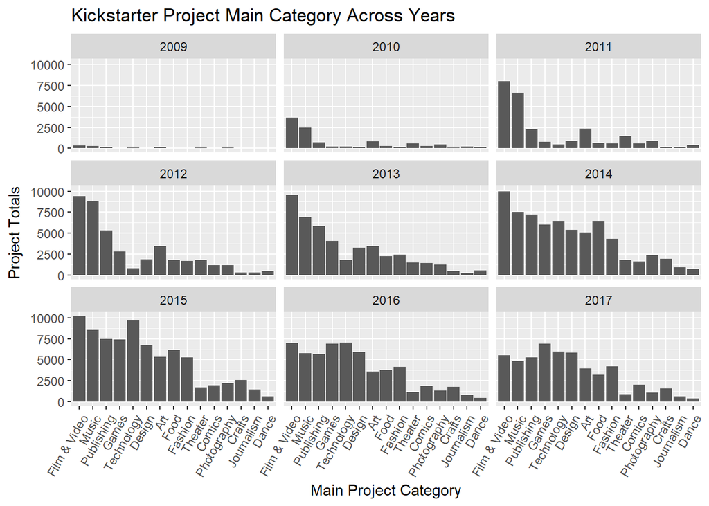

```r
ks %>%
  filter(launch_year < 2018) %>%
  ggplot(aes(x = main_category), y = count(main_category)) +
  geom_bar() + facet_wrap(~launch_year) +
  theme(axis.text.x = element_text(angle= 60, hjust=1)) +
  labs(x = "Main Project Category", y = "Project Totals") +
  ggtitle("Kickstarter Project Main Category Across Years")
```

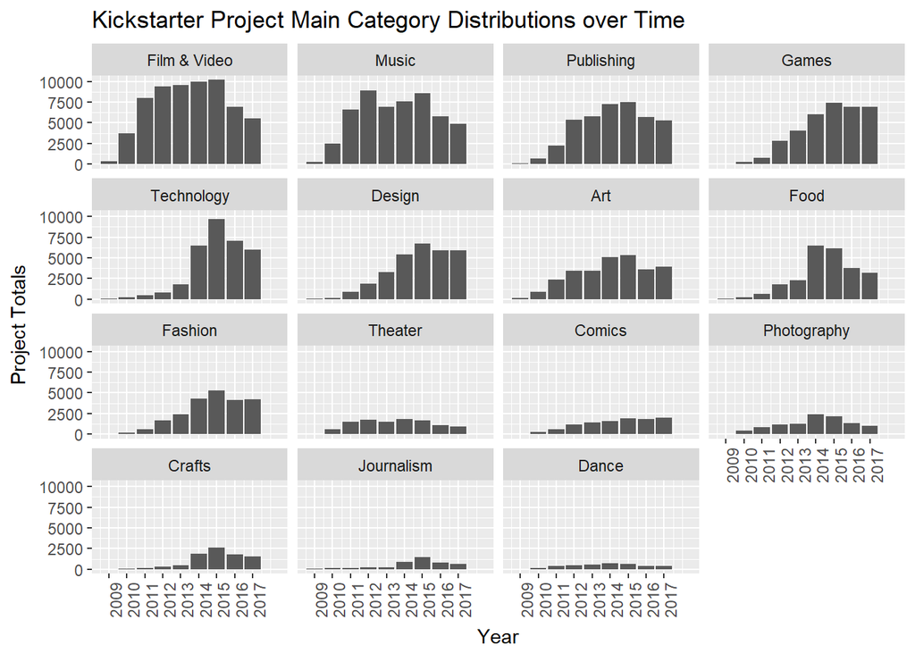

```r
ks %>%
  filter(launch_year <= 2018) %>%
  ggplot(aes(x = launch_year), y = count(main_category)) +
  geom_bar() + facet_wrap(~main_category) +
  theme(axis.text.x = element_text(angle= 90, hjust=1)) +
  labs(x = "Year", y = "Project Totals") +
  ggtitle("Kickstarter Project Main Category Distributions over Time") +
  scale_x_continuous(breaks = c(2009,2010,2011,2012,2013,2014,2015,2016,2017))
```

## Successful Project Categories

Now let’s see the percentage of successful projects (using main category). I’ll have to mutate a new column to get the quantity I want. Here’s more on mutate: https://dplyr.tidyverse.org/reference/mutate.html.

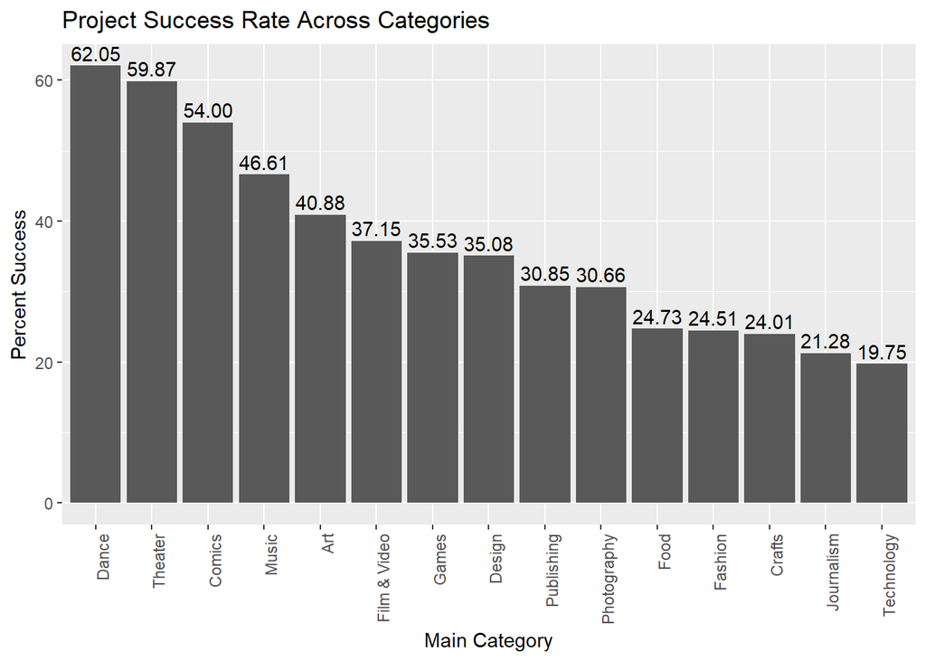

```r
ks %>%

  group_by(main_category) %>%
  summarize(pct_success = (sum(state == "successful")/length(main_category)) * 100) %>%
  arrange(desc(pct_success)) %>%
  ggplot(aes(x = reorder(main_category, - pct_success), y = pct_success)) +
  geom_bar(stat = "identity") +
  theme(axis.text.x = element_text(angle= 90, hjust=1)) +
  geom_text(aes(label=sprintf("%0.2f", round(pct_success, digits = 2))), vjust = -.35) +
  labs(x = "Main Category", y = "Percent Success") +
  ggtitle("Project Success Rate Across Categories")
```

```r
pct_film_dance = (sum(ks$main_category == "Dance")/length(ks$ID)) * 100
pct_film_dance
```

```
## [1] 0.9950853
```

```r
pct_film_theater = (sum(ks$main_category == "Theater")/length(ks$ID)) * 100
pct_film_theater
```

```
## [1] 2.881997
```

The most successful Kickstarter projects are Dance and Theater, yet those categories only make up about 1% and 3% of all projects.

## What categories are the top-10 funded projects?

Let’s see where the money is going by looking at the highest-funded projects total.

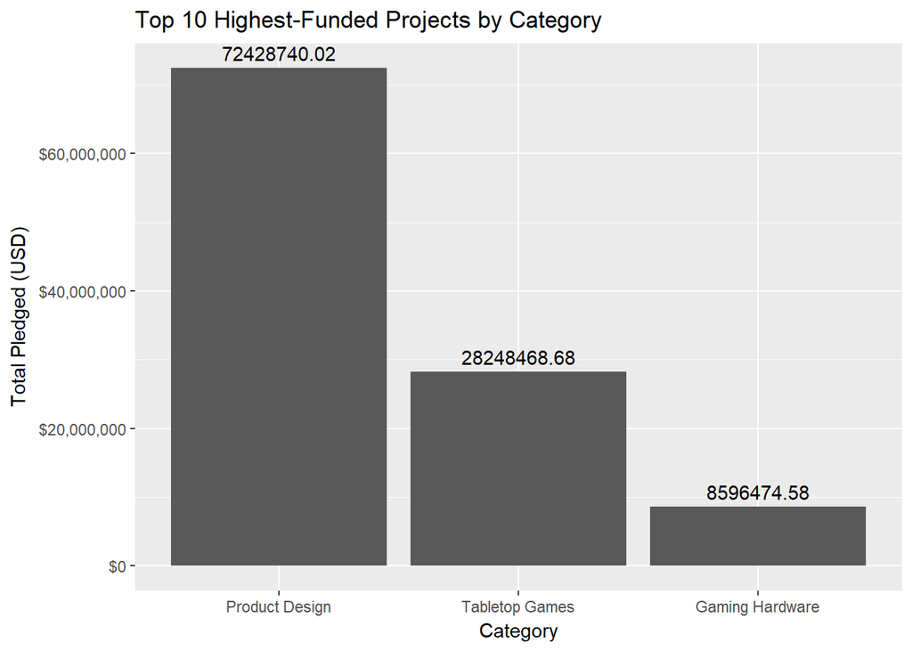

```r
ksp <- ks %>%
  select(usd_pledged, name, category, main_category, state) %>%
  arrange(desc(usd_pledged)) %>%
  slice(1:10)

ksp %>%
  group_by(category) %>%
  summarize(tot_pledged = sum(usd_pledged))%>%
  ggplot(aes(x = reorder(category, -tot_pledged), y = tot_pledged)) +
  geom_bar(stat = "identity") +
  geom_text(aes(label = tot_pledged), vjust = -.5) +
  labs(x = "Category", y = "Total Pledged (USD)") +
  scale_y_continuous(labels = scales::dollar)  +
  ggtitle("Top 10 Highest-Funded Projects by Category")
```

```r
pdesign_pct =(sum(ks$category == "Product Design")/length(ks$ID)) * 100
pdesign_pct
```

```
## [1] 5.89287
```

## Which categories get the most funding overall?

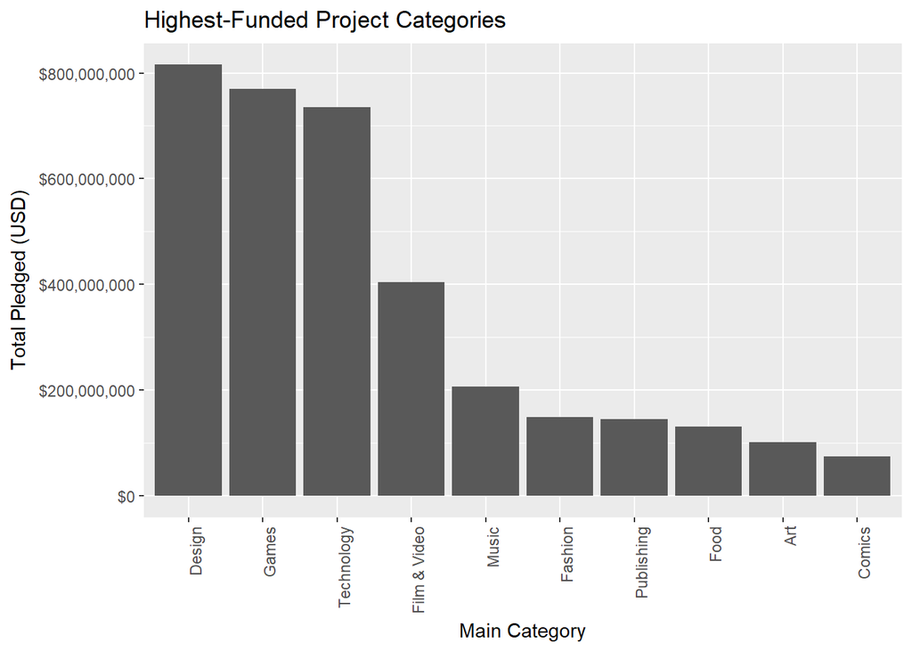

```r
ks_money_sub <- ks %>%
  group_by(category) %>%
  summarize(total_pledged = sum(pledged)) %>%
  arrange(desc(total_pledged)) %>%
  slice(1:10) %>%
  ggplot(aes(x = reorder(category, -total_pledged), y = total_pledged)) +
  geom_bar(stat = "identity") +
  theme(axis.text.x = element_text(angle= 90, hjust=1)) +
  labs(x = "Category", y = "Total Pledged (USD)") +
  scale_y_continuous(labels = scales::dollar) +
  ggtitle("Highest-Funded Project Subcategories")


ks_money_main <- ks %>%
  group_by(main_category) %>%
  summarize(total_pledged = sum(pledged)) %>%
  arrange(desc(total_pledged)) %>%
  slice(1:10) %>%
  ggplot(aes(x = reorder(main_category, -total_pledged), y = total_pledged)) +
  geom_bar(stat = "identity") +
  theme(axis.text.x = element_text(angle= 90, hjust=1)) +
  labs(x = "Main Category", y = "Total Pledged (USD)") +
  scale_y_continuous(labels = scales::dollar) +
  ggtitle("Highest-Funded Project Categories")


ks_money_main
```

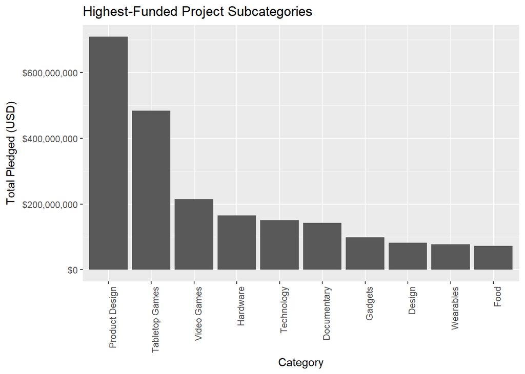

```r
ks_money_sub
```

Design (and namely its subcategory Product Design) receive the most funding.

## Analyzing Funding Percentiles

What happens to your project if you are over or under your funding goal? Here I will create a percent difference column between funding goal and funding amount. Then I’ll use the cut function to create 10 breaks in the percentages, effectively creating percentiles. Here is some more info on R’s cut function: https://www.rdocumentation.org/packages/base/versions/3.5.0/topics/cut.

In order to calculate success rates, I’ll consider a success the total number of “successful” states out of all states, and I’ll factor out the “live” and “undefined” states as they are ambiguous. For failure rate, I consider a project failed if it is “failed”, “canceled”, or “suspended”. I then add these failure rates per percentile range to a new dataframe.

```r
ks_pct <- ks

ks_pct <- ks_pct %>%

  mutate(difference = usd_pledged - usd_goal) %>%
  mutate(pct_diff = (difference/(usd_goal+usd_pledged))*100) %>%
  filter(pct_diff >0 ) %>%
  mutate(intervals = cut(pct_diff, breaks =  10))

pos<-ks_pct %>%
  group_by(intervals) %>%
  summarize(fail_per_interval = ((sum(state == "failed") + sum(state == "canceled") + sum(state == "suspended"))/(length(state)-sum(state == "live") - sum(state=="undefined")) *100))

neg<-ks_pct %>%
  group_by(intervals) %>%
  summarize(success_per_interval = (sum(state=="successful")/(length(state)-sum(state == "live")-sum(state == "undefined"))*100))


intervals_pos_df <- left_join(pos,neg,by="intervals")

intervals_pos_df
```

```
## # A tibble: 10 x 3
##    intervals fail_per_interval success_per_interval
##    <fct>                 <dbl>                <dbl>
##  1 (-0.1,10]             0.389                 99.6
##  2 (10,20]               0.743                 99.3
##  3 (20,30]               0.875                 99.1
##  4 (30,40]               1.46                  98.5
##  5 (40,50]               1.21                  98.8
##  6 (50,60]               1.63                  98.4
##  7 (60,70]               1.70                  98.3
##  8 (70,80]               0.782                 99.2
##  9 (80,90]               1.25                  98.8
## 10 (90,100]              2.88                  97.1
```

Now let’s do the same thing, but see if there are projects that don’t meet their goal and end up succeeding.

```r
ks_pct_neg <- ks

ks_pct_neg <- ks_pct_neg %>%

  mutate(difference = usd_pledged - usd_goal) %>%
  mutate(pct_diff = (difference/(usd_goal+usd_pledged))*100) %>%
  filter(pct_diff <= 0) %>%
  mutate(intervals = cut(pct_diff, breaks =  10))

pos<-ks_pct_neg %>%
  group_by(intervals) %>%
  summarize(fail_per_interval = ((sum(state == "failed") + sum(state == "canceled") + sum(state == "suspended"))/(length(state)-sum(state == "live") - sum(state=="undefined")) *100))

neg<-ks_pct_neg %>%
  group_by(intervals) %>%
  summarize(success_per_interval = (sum(state=="successful")/(length(state)-sum(state == "live")-sum(state == "undefined"))*100))

intervals_neg_df <- left_join(pos,neg,by="intervals")


intervals_neg_df
```

```
## # A tibble: 10 x 3
##    intervals  fail_per_interval success_per_interval
##    <fct>                  <dbl>                <dbl>
##  1 (-100,-90]             100                    0
##  2 (-90,-80]              100                    0
##  3 (-80,-70]              100                    0
##  4 (-70,-60]              100                    0
##  5 (-60,-50]              100                    0
##  6 (-50,-40]              100                    0
##  7 (-40,-30]              100                    0
##  8 (-30,-20]              100                    0
##  9 (-20,-10]              100                    0
## 10 (-10,0.1]               19.3                 80.7
```

From here, one thing is clear, if you are short on funding from over 10 to 100% of your Kickstarter goal, there is no chance of success! However, if you are within 10% of reaching your goal, things still look up, as you have over an 80% chance of success.

## Standardizing Success Rates

Now let’s see how successes compare across categories relative to one another. I will do this by standardizing success rates by category. This way, we can see if there really are projects that perform better than others on average. Heres a bit more on standardization in R: http://stats.seandolinar.com/calculating-z-scores-with-r/.

```r
std <- ks

stdize <- std %>%
  group_by(main_category, launch_year) %>%
  summarize(cat_success = mean((sum(state == "successful")/length(main_category))))

stdize <- stdize%>%
  mutate(avg_success = (sum(std$state == "successful")/length(std$state))) %>%
  mutate(stdized_success = (cat_success-avg_success)/sd(cat_success))

stdize
```

```
## # A tibble: 149 x 5
## # Groups:   main_category [15]
##    main_category launch_year cat_success avg_success stdized_success
##    <fct>               <dbl>       <dbl>       <dbl>           <dbl>
##  1 Film & Video         2009       0.377       0.354          0.186
##  2 Film & Video         2010       0.400       0.354          0.368
##  3 Film & Video         2011       0.414       0.354          0.488
##  4 Film & Video         2012       0.401       0.354          0.382
##  5 Film & Video         2013       0.423       0.354          0.553
##  6 Film & Video         2014       0.361       0.354          0.0622
##  7 Film & Video         2015       0.294       0.354         -0.477
##  8 Film & Video         2016       0.346       0.354         -0.0664
##  9 Film & Video         2017       0.345       0.354         -0.0676
## 10 Film & Video         2018       0           0.354         -2.85
## # ... with 139 more rows
```

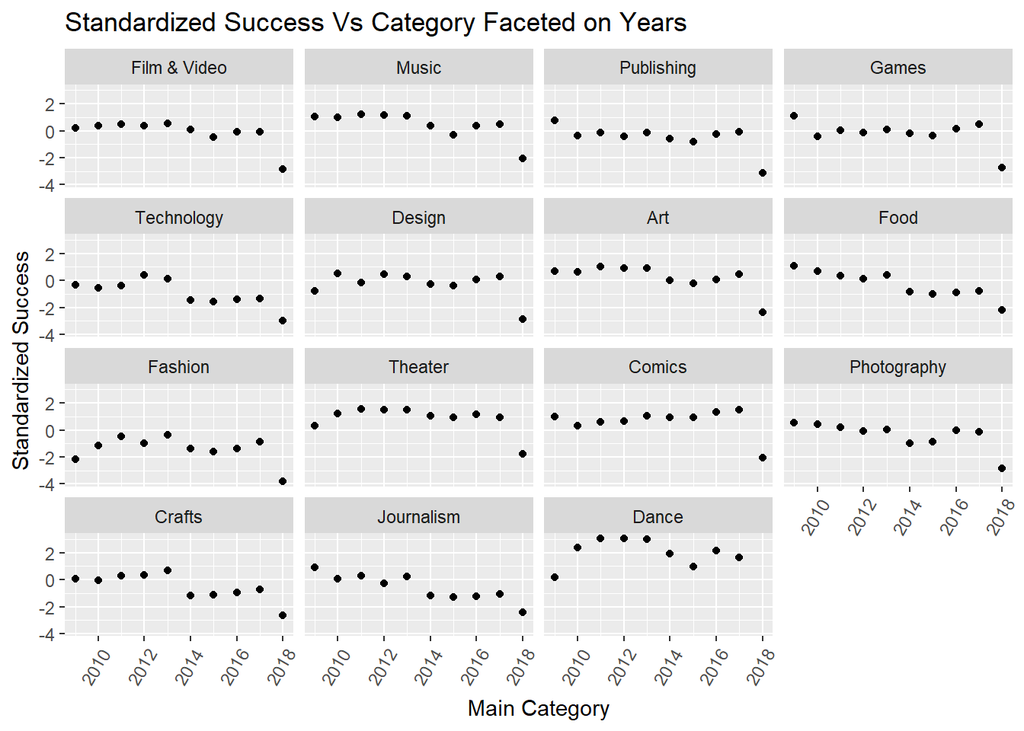

```r
stdize %>%
  ggplot(aes(x = launch_year, y = stdized_success)) +
  ggtitle("Standardized Success Vs Category Faceted on Years") +
  geom_point() +
  facet_wrap(~main_category) +
  theme(axis.text.x = element_text(angle= 60, hjust=1)) +
  labs(x="Main Category",
       y = "Standardized Success")
```

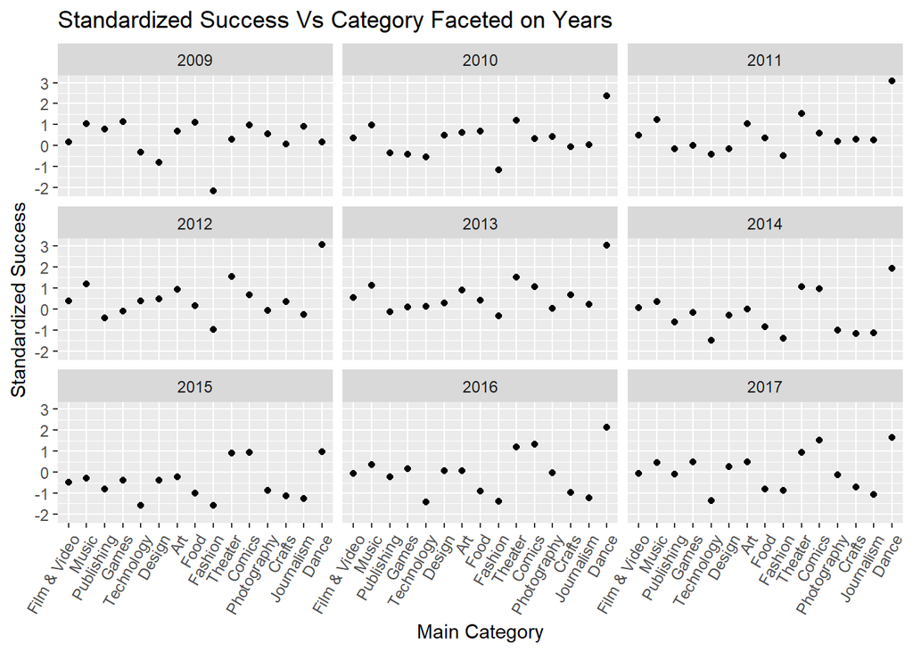

```r
stdize %>%
  filter(launch_year < 2018) %>%
  ggplot(aes(x = main_category, y = stdized_success)) +
  ggtitle("Standardized Success Vs Category Faceted on Years") +
  geom_point() +
  facet_wrap(~launch_year) +
  theme(axis.text.x = element_text(angle= 60, hjust=1)) +
  labs(x="Main Category",
       y = "Standardized Success")
```

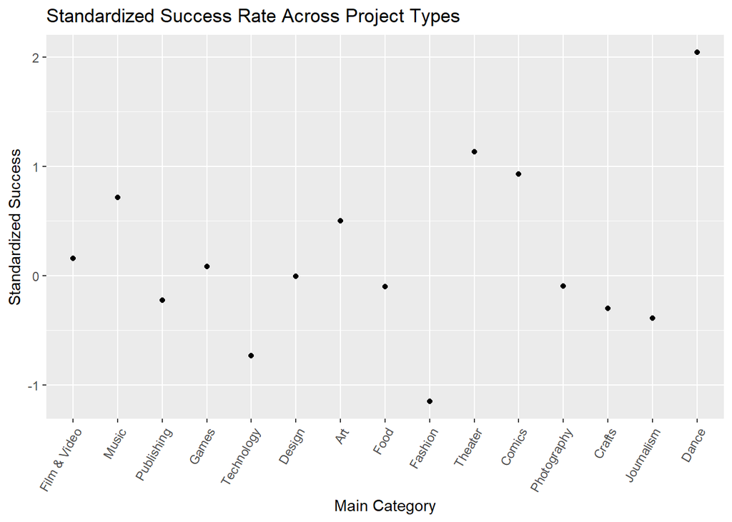

```r
stdize %>%
  filter(launch_year < 2018) %>%
  group_by(main_category) %>%
  summarize(avg_succ = mean(stdized_success)) %>%
  ggplot(aes(x = main_category, y = avg_succ)) +
  ggtitle("Standardized Success Rate Across Project Types") +
  geom_point() +
  theme(axis.text.x = element_text(angle= 60, hjust=1)) +
  labs(x="Main Category",
       y = "Standardized Success")
```

Even when standardizing success rate, we see that art-related projects have higher success rates on average, especially dance.

## How do projects succeed over time?

It may also be interesting to see how people give money over time. Namely, does having a longer project imply success? Let’s use a linear model to find out. First, we have to get some time differences between the project launch and deadline. Let’s get an average success rate based on the number of days a project is live. We’ll do this by subtracting the launch date from the deadline column.

```r
len_vs_succ <- ks

len_vs_succ <- len_vs_succ%>%
  mutate(proj_len = as.numeric(deadline-launched)) %>%
  group_by(proj_len) %>%
  summarize(succ_pct = (sum(state=="successful")/(length(state)-sum(state == "live")-sum(state == "undefined"))))

len_vs_succ <- len_vs_succ %>%
  filter(proj_len <= 70)

len_vs_succ
```

```
## # A tibble: 70 x 2
##    proj_len succ_pct
##       <dbl>    <dbl>
##  1     1.00    0.343
##  2     2.00    0.367
##  3     3.00    0.317
##  4     4.00    0.393
##  5     5.00    0.402
##  6     6.00    0.434
##  7     7.00    0.454
##  8     8.00    0.529
##  9     9.00    0.543
## 10    10.0     0.437
## # ... with 60 more rows
```

## Hypothesis Testing

Now that we’ve prepared our data by getting time (in days), and success rate, we should test whether length of time affects success rate of projects. Let’s do this via a hypothesis test. Our null hypothesis will be that there is no relationship between the amount of days a project is open and success rate of projects. If you’re new to Hypothesis Testing or would like some more information, check http://www.r-tutor.com/elementary-statistics/hypothesis-testing out.

```r
len_vs_succ %>%
  lm(proj_len~succ_pct, data=.) %>%
  broom::tidy()
```

```
##          term   estimate std.error statistic      p.value
## 1 (Intercept)   80.12621  10.70945  7.481822 1.910451e-10
## 2    succ_pct -104.32524  24.51319 -4.255881 6.528931e-05
```

To interpret these results, we first look at the p-value for succ_pct. The p-value is 0.0000652, which is much less than the alpha we are using (by default) in our test, so we reject the null hypotheses that there is no relationship between the days a project is live and success rate. In fact, since the estimate of succ_pct is large and negative, this implies that there is a strong negative relationship between the two. Let’s see if a visualization can help us see the relationship more clearly by plotting project length (in days) versus average success rate as a percentage.

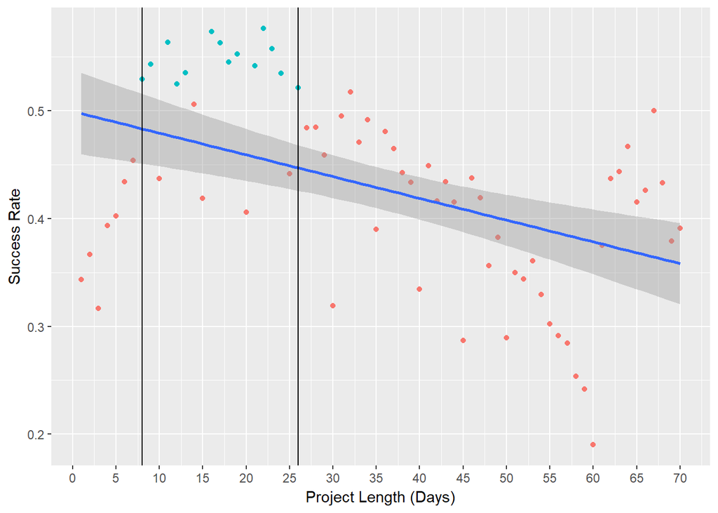

```r
len_vs_succ_plt  <- len_vs_succ

len_vs_succ_plt %>%
  ggplot(aes(x = proj_len, y = succ_pct)) +
  labs(x = "Project Length (Days)", y = "Success Rate") +
  geom_point(aes(color = succ_pct > 0.52)) +
  geom_smooth(method = lm) +
  scale_x_continuous(breaks = c(0,5,10,15,20,25,30,35,40,45,50,55,60,65,70)) +
  theme(legend.position = "none") +
  geom_vline(xintercept=8, color="black") +
  geom_vline(xintercept=26, color="black")
```

```r
len_vs_succ
```

```
## # A tibble: 70 x 2
##    proj_len succ_pct
##       <dbl>    <dbl>
##  1     1.00    0.343
##  2     2.00    0.367
##  3     3.00    0.317
##  4     4.00    0.393
##  5     5.00    0.402
##  6     6.00    0.434
##  7     7.00    0.454
##  8     8.00    0.529
##  9     9.00    0.543
## 10    10.0     0.437
## # ... with 60 more rows
```

The above plot verifies our regression model output. There definitely is a strong negative relationship between length of days a project is live and its success rate. I have highlighted highly sucessful days and denoted their range with vertical lines for clarity.

# Concluding